# Probability Distribution

Wanyu LIN

# Discrete Distributions

## Bernoulli distribution

A *Bernoulli trial* is a simple random experiment with two outcomes: success $(1)$ or failure $(0)$. The success probability is $p$, so the failure probability is $q=1-p$. A Bernoulli random variable $X$ describes this:
$$\begin{eqnarray*}
X =
\left\{
\begin{array}{ll}
1 & \mbox{success - probability $p$} \\
0 & \mbox{failure - probability $q=1-p$}
\end{array}
\right.
\end{eqnarray*}$$

The probability mass function (PMF) is given by:
$$p_X (x) = p^x (1-p)^{1-x} \qquad x=0,1$$
Note that if $x =1$, $p_X (1) = p^1 q^0 = p$ and if $x=0$, $p_X (0) = p^0 q^1 = q$.

The cumulative distribution function (CDF) is given by:
$$F_X(x) = \left\{ \begin{array}{ll} 0 \qquad
& \mbox{if } x <0 \\
1-p \qquad & \mbox{if } 0 \leq x <1 \\ 1 \qquad & \mbox{if }
x \geq 1. \end{array} \right.$$

We also have the expectation and variance:
$$E[X]= p,\qquad \mbox{var}(X) = pq.$$

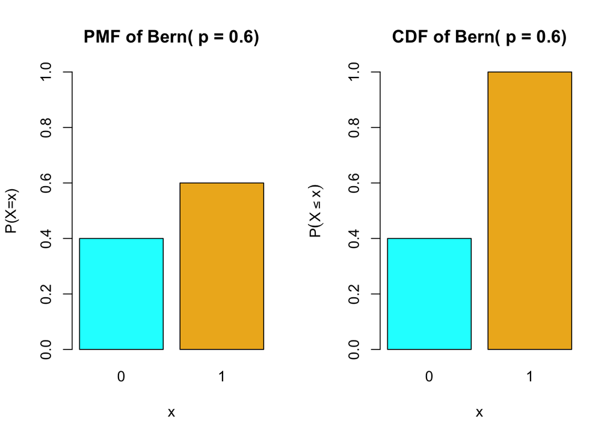

## Binomial Distritbtion

Consider $n$ independent Bernoulli trials, each with success probability $p$. Let $X$ be the total number of successes. Then $X$ has a *Binomial* distribution, written

$$X \sim {\rm Bin}(n,p), \; \; \mbox{or } X \sim {\rm B}(n,p)$$

and for $k = 0, 1, \ldots, n$,

$$p_X(k) = P(X = k) = \binom{n}{k} p^{k}(1-p)^{n-k} .$$

The cumulative distribution function of binomial distribution is

$$F_X(x)=P(X \leq x)=\sum_{k=0}^{\lfloor x \rfloor}\binom{n}{k}
p^k(1-p)^{n-k},$$

where $\lfloor x \rfloor$ is the floor function (the greatest integer not greater than $x$).

For the binomial random variable, $E[X] = n p$ and $\mbox{var}(X) = n p(1-p)$.

The mode is:

$$\text { mode }=\left\{\begin{array}{lll}
(n+1) p & \text { and } & (n+1) p-1 & \text { if } (n+1) p
\text { is an integer }\\
\lfloor(n+1) p\rfloor & & & \text { if } (n+1) p \text { is
not an integer }
\end{array}\right.$$
The median satisfies $\lfloor n p\rfloor \leq m \leq \lceil n p\rceil$, where $\lfloor n p\rfloor$ is the floor function, and $\lceil n p\rceil$ is the ceiling function (the smallest integer greater than or equal to $np$).

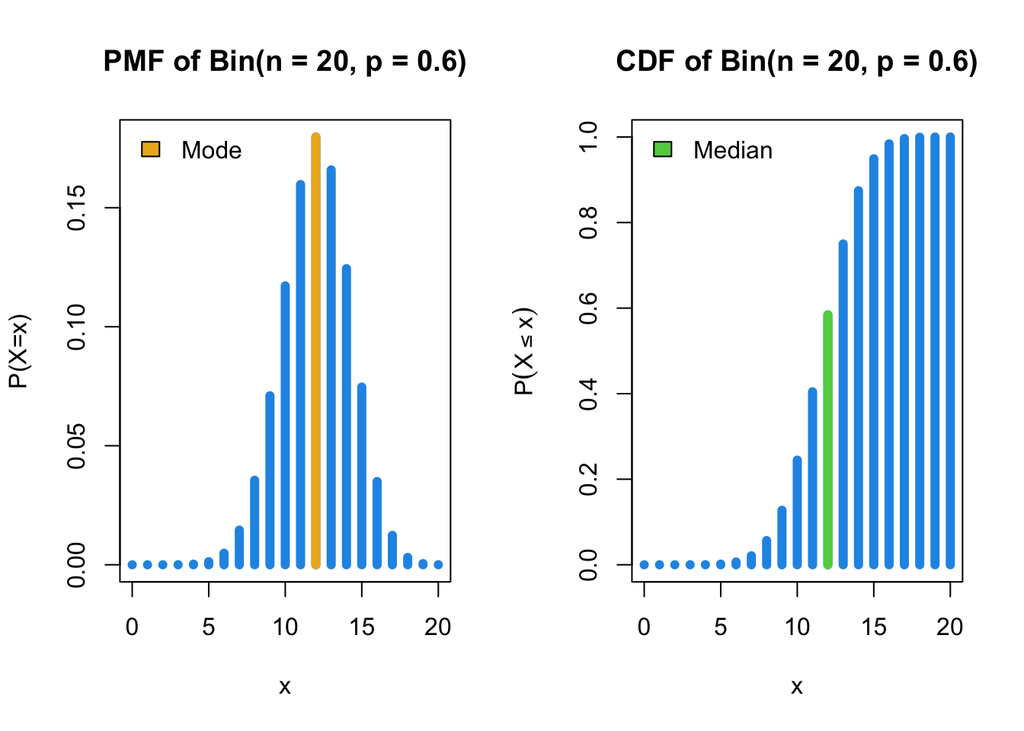

## Geometric Distribution

The geometric distribution models the number of trials until the first success.

For $X \sim \text{Geom}(p)$, the probability mass function (PMF) is:

$$p_X(k) = (1-p)^{k-1} p, \quad k = 1, 2, 3, \ldots$$

The cumulative distribution function (CDF) is:

$$F_X(x) = 1 - (1-p)^{\lfloor x \rfloor}$$

Expectation and Variance:

$$E[X] = \frac{1}{p}, \quad \text{var}(X) = \frac{1-p}{p^2}$$

The median is:
$$\text {median} = \left\lceil \frac{-\log(2)}{\log(1 - p)} \right\rceil$$

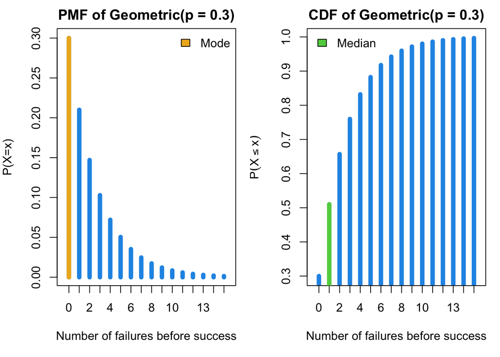

### Further discussion of relevant property: Memoryless Property

For $s, t > 0$:

$$P(X > s + t \mid X > s) = P(X > t)$$

## Negative Binomial Distribution

Let X mean the total number of independent Bernoulli trials needed to obtain exactly r successes. Then, X follows the negative binomial distribution with Probability Mass Function (PMF):

$$p_X(k) = P(X = k) = \binom{k- 1}{r - 1} p^r (1-p)^{k-r}, \quad k = r,
r+1, \ldots$$

For k < r: P(X = k) = 0

The Cumulative Distribution Function (CDF) is:
$$F_X(x) = P(X \le x) = \sum_{i=r}^{\lfloor x \rfloor} \binom{i-1}{r-1}
p^r (1-p)^{i-r}$$

where $\lfloor x \rfloor$ denotes the floor function (greatest integer ≤ x).

Expectation:
$$\mathbb{E}[X] = \frac{r}{p}$$

Variance:
$$\text{Var}(X) = \frac{r(1-p)}{p^2}$$

The mode is:
$$\lfloor \frac{r+p-1}{p} \rfloor$$
.

There is no simple closed-form expression for the median of the negative binomial distribution. The median m satisfies:
$$P(X \le m) \ge 0.5 \quad \text{and} \quad P(X \ge m) \ge 0.5$$

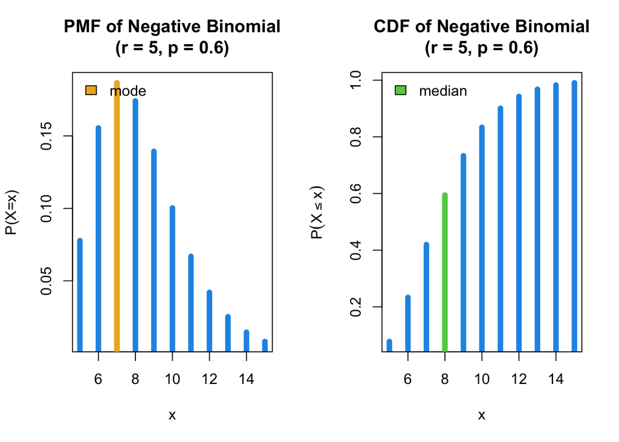

### Further discussion: Relation to another probability distribution

The **negative binomial** distribution $X \sim \text{NegBin}(r, p)$ is the sum of $r$ independent **geometric** distributions $G \sim \text{Geom}(p)$. When $r = 1$, the negative binomial reduces to the **geometric distribution**.

Similarly, the **binomial** distribution $Y \sim \text{Bin}(n, p)$ is the sum of $n$ independent **Bernoulli** random variables with success probability $p$ (the first two distrbutions listed in this file).

## Discrete Uniform Distribution

Let $X$ be a number selected uniformly at random from $a, a+1, \ldots, a+b$, and $a$ and $b$ are integers. Then $X$ is a discrete uniform random variable.

The probability mass function (PMF) is given by:

$$p_X(x) = P(X = x) = \frac{1}{b+1}, \quad \text{for } x = a, a+1, \ldots,
a+b$$

The cumulative distribution function (CDF)is:

$$F_X(x) = P(X \leq x) =
\begin{cases}
0 & \text{if } x < a \\
\frac{\lfloor x \rfloor - a + 1}{b+1} & \text{if } a \leq x \leq a+b
\\
1 & \text{if } x > a+b
\end{cases}$$

where $\lfloor x \rfloor$ is the floor function (the greatest integer less than or equal to $x$).

The Expectation (mean) and Variance are:

$$E[X] = a + \frac{b}{2}$$

$$\operatorname{Var}(X) = \frac{1}{12} b(b+2)$$

The mode: Since all values are equally likely, every $x \in \{a, a+1, \ldots, a+b\}$ is a mode.

The median:

- If $(b+1)$ is odd: $\text{median} = a + \frac{b}{2}$
- If $(b+1)$ is even: $\text{median} = \left[a + \frac{b-1}{2}, a + \frac{b+1}{2}\right]$ (any value in this interval)

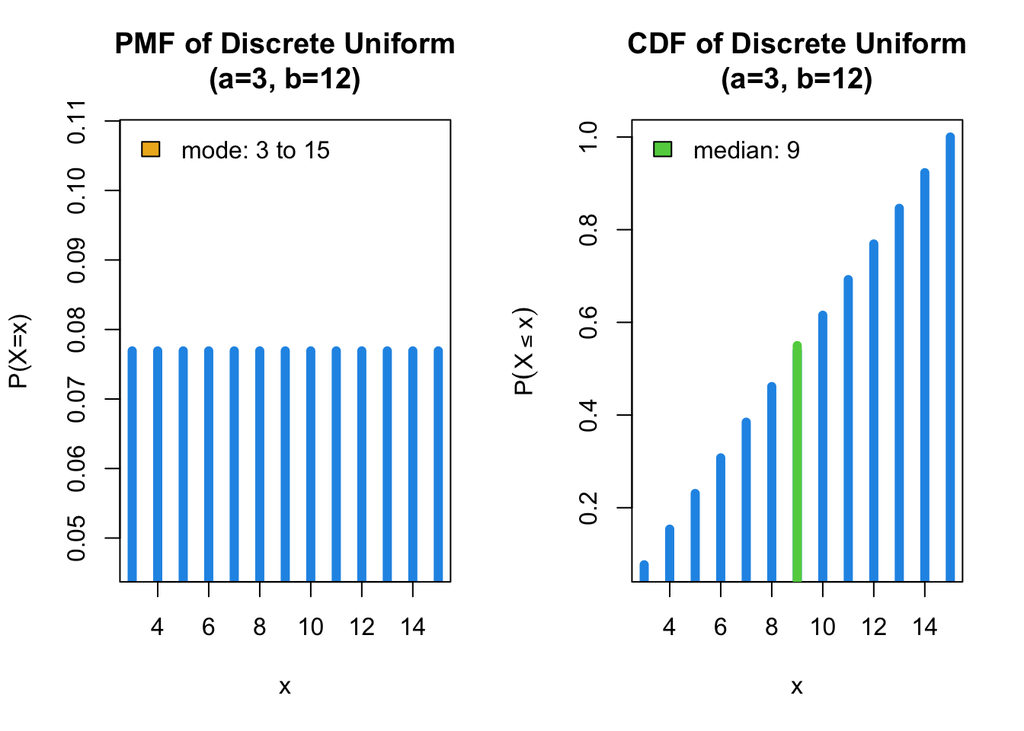

## Poisson Distribution

The Poisson distribution models the number of events occurring in a fixed interval of time or space, when these events occur independently at a constant average rate $\lambda \ (\lambda>0)$, written as $X \sim Po(\lambda)$.

The Probability Mass Function (PMF) gives the probability of observing exactly $k$ events:

$$p_X(k) = P(X = k) = e^{-\lambda} \frac{\lambda^k}{k!}, \quad k = 0, 1,
2, \ldots$$

The Cumulative Distribution Function (CDF) gives the probability of observing at most $k$ events:

$$F_X(k) = P(X \leq k) = \sum_{i=0}^{k} e^{-\lambda} \frac{\lambda^i}{i!},
\quad k = 0, 1, 2, \ldots$$

Both the Expectation (mean) and Variance of a Poisson distribution equal $\lambda$:

$$E[X] = \lambda, \quad \operatorname{Var}(X) = \lambda$$

The most likely number of events (mode) is the integer part of $\lambda$:

$$\text{Mode} = \lfloor \lambda \rfloor$$

When $\lambda$ is an integer, both $\lambda$ and $\lambda-1$ are modes.

There is no simple formula for the median. It is the value $m$ where:

$$P(X \leq m) \geq 0.5 \quad \text{and} \quad P(X \geq m) \geq 0.5$$

### Further discussion: Poisson Approximation to Binomial

When $n$ is large and $p$ is small, a Binomial distribution can be approximated by a Poisson distribution:

$$\text{Bin}(n, p) \approx \text{Po}(np)$$

This works well when $n \geq 20$ and $p \leq 0.05$, or $n \geq 100$ and $np \leq 10$.

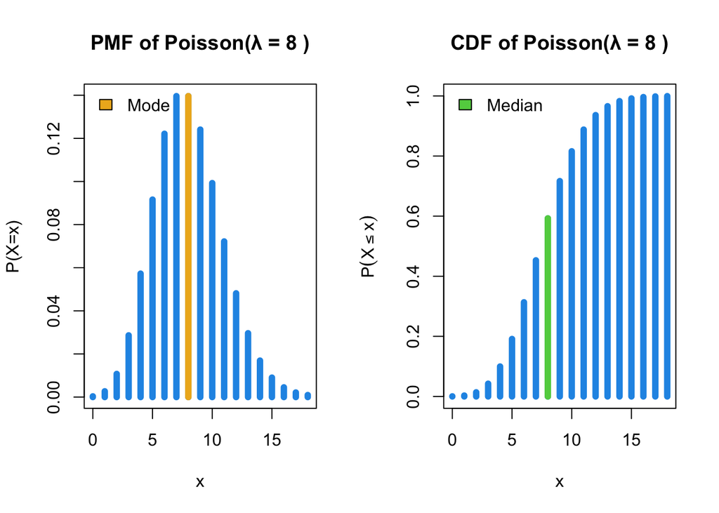

## Hypergeometric Distribution

The hypergeometric distribution is to model sampling without replacement from a finite population. Example: drawing colored balls from a container without putting them back.

An container has $A$ white balls and $B$ black balls. We draw $n$ balls without replacement. Let $X$ be the number of white balls drawn. Then $X$ has a hypergeometric distribution.

The Probability Mass Function (PMF) is (the probability of drawing exactly $k$ white balls):

$$p_X(k) = P(X = k) = \frac{\binom{A}{k} \binom{B}{n-k}}{\binom{A+B}{n}}$$

for:
$$\max(0, n-B) \leq k \leq \min(A,
n)$$

The Cumulative Distribution Function (CDF) is (the probability of drawing at most $k$ white balls):

$$F_X(k) = P(X \leq k) = \sum_{i=0}^{k} \frac{\binom{A}{i}
\binom{B}{n-i}}{\binom{A+B}{n}}$$

The Expectation (mean) is the expected number of white balls drawn:

$$E[X] = \frac{nA}{A+B}$$

The Variance is the variability in the number of white balls drawn:

$$\operatorname{Var}(X) = \frac{ABn(A+B-n)}{(A+B)^2(A+B-1)}$$

The Mode is (the most likely number of white balls drawn):
$$\text{mode}={\lfloor \frac{(A+1)(n+1)}{A+B+2} \rfloor}$$

The median is the middle value where half the probability is below and half above. It also depends on $A$, $B$, and $n$.

### Further discussion: Relation to another probability distribution

This distribution models **without replacement** sampling. For **with replacement** sampling, we need to use the Binomial distribution instead.

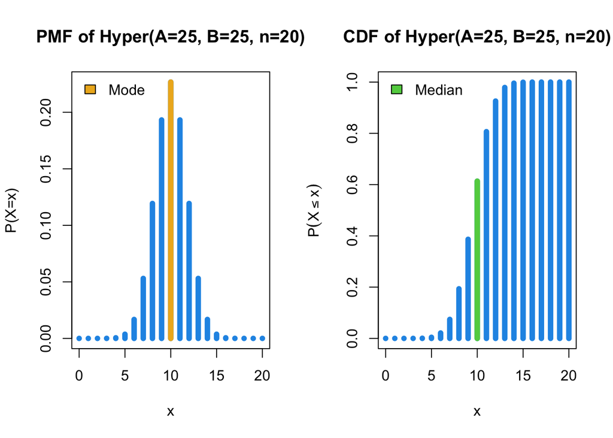

# Continuous distributions

## Continuous Uniform Distribution

Let $X$ be a continuous random variable uniformly distributed on the interval $[a, b]$, written $X \sim U(a, b)$. All values in the interval are equally likely.

The Probability Density Function (PDF) gives the relative likelihood of $X$ taking a value near $x$:

$$f_X(x) =
\begin{cases}
\frac{1}{b - a} & \text{for } a < x < b \\
0 & \text{otherwise}
\end{cases}$$

The Cumulative Distribution Function (CDF) gives the probability that $X$ is less than or equal to $x$:

$$F_X(x) =
\begin{cases}
0 & \text{for } x \leq a \\
\frac{x - a}{b - a} & \text{for } a < x < b \\
1 & \text{for } x \geq b
\end{cases}$$

The Expectation and Variance of the distribution:

$$E[X] = \frac{a + b}{2}$$

$$\operatorname{Var}(X) = \frac{(b - a)^2}{12}$$

Mode: The continuous uniform distribution has no unique mode. Every point in $[a, b]$ is equally likely.

The median equals the mean:

$$\text{Median} = \frac{a + b}{2}$$

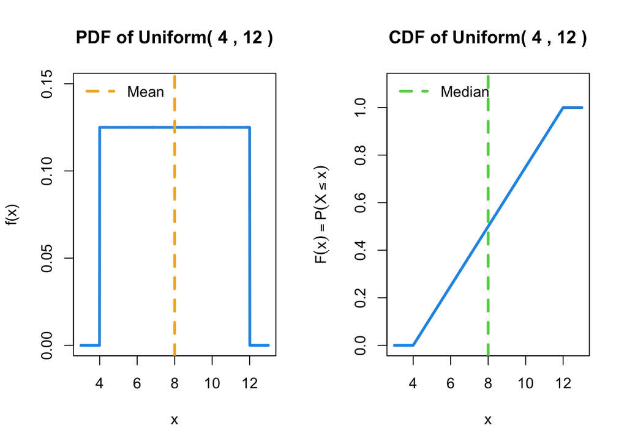

## Exponential Distribution

Let $T$ be a continuous random variable following an exponential distribution with rate parameter $\lambda > 0$, written $T \sim \text{Exp}(\lambda)$. This distribution models the time between events in a Poisson process.

The Probability Density Function (PDF) for $T > 0$:

$$f_T(t) = \lambda e^{-\lambda t}, \quad t > 0$$

and
$$f_T(t) = 0\ for\ t \leq
0.$$

The Cumulative Distribution Function (CDF) for $t > 0$:

$$F_T(t) = 1 - e^{-\lambda t}, \quad t > 0$$

and
$$F_T(t) = 0\ for\ t \leq
0.$$

The Expectation (average time) and Variance:

$$E[T] = \frac{1}{\lambda}$$

$$\operatorname{Var}(T) = \frac{1}{\lambda^2}$$

The mode is:

$$\text{Mode} = 0$$

The median (time where $P(T \leq t) = 0.5$) is:

$$\text{Median} = \frac{\ln(2)}{\lambda}$$

### Further discussion of relevant property: Memoryless Property

For $s, t > 0$:

$$P(T > s + t \mid T > s) = P(T > t)$$

### Further discussion: Relations between Exponential, Poisson, and Gamma distributions

1. **Connection to Poisson distribution**: The Poisson distribution accounts for the number of events in a fixed interval, and the Exponential distribution measures the waiting time between one event and the next in the same Poisson process.
2. **Connection to Gamma distribution**: The Gamma distribution models the *waiting time for the r-th event* in a Poisson process; it simplifies to the Exponential distribution when $\alpha=1$ (in Gamma distribution), meaning Exponential is a special case of Gamma.

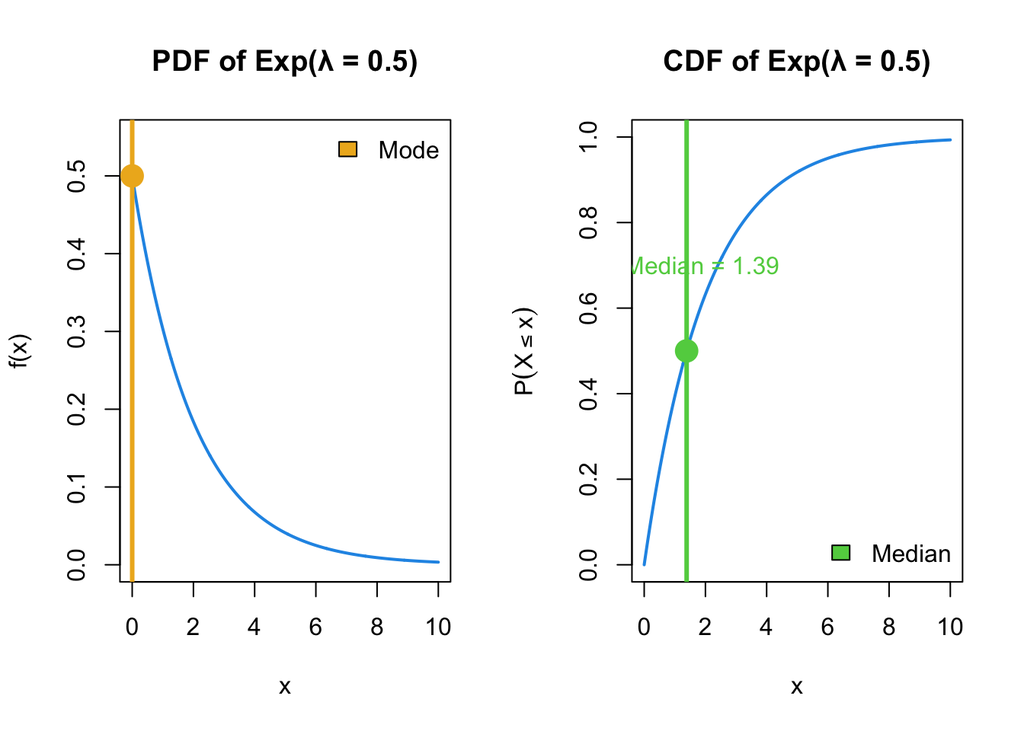

## Gamma Distribution

Let $X$ be a continuous random variable following a Gamma distribution with shape parameter $\alpha > 0$ and rate parameter $\beta > 0$, written $X \sim \text{Gamma}(\alpha, \beta)$. The Gamma distribution generalizes the exponential distribution.

The Probability Density Function (PDF):  
For $x > 0$:

$$f_X(x) = \frac{\beta^\alpha}{\Gamma(\alpha)} x^{\alpha-1} e^{-\beta x}$$

where $\Gamma(\alpha)$ is the Gamma function:
$$\Gamma(\alpha) =
\int_{0}^{\infty} y^{\alpha-1} \exp(-y) dy$$

For $x \leq 0$:
$$f_X(x) = 0$$

The Cumulative Distribution Function (CDF) for $x > 0$:

$$F_X(x) = \frac{\gamma(\alpha, \beta x)}{\Gamma(\alpha)}$$

where $\gamma(\alpha, \beta x)$ is the lower incomplete Gamma function, and $F_X(x) = 0$ for $x \leq 0$.

The Expectation and Variance:

$$E[X] = \frac{\alpha}{\beta}$$

$$\operatorname{Var}(X) = \frac{\alpha}{\beta^2}$$

Mode:  
For $\alpha \geq 1$:

$$\text{Mode} = \frac{\alpha - 1}{\beta}$$

For $\alpha < 1$, mode is at $x = 0$.

No simple closed-form expression. The median $m$ satisfies $F_X(m) = 0.5$.

### Further discussion of relation to another probability distribution

- When $\alpha = 1$, Gamma distribution becomes Exponential distribution.
- When $\alpha$ is integer, Gamma distribution could be considered as the sum of $\alpha$ exponential distributions.

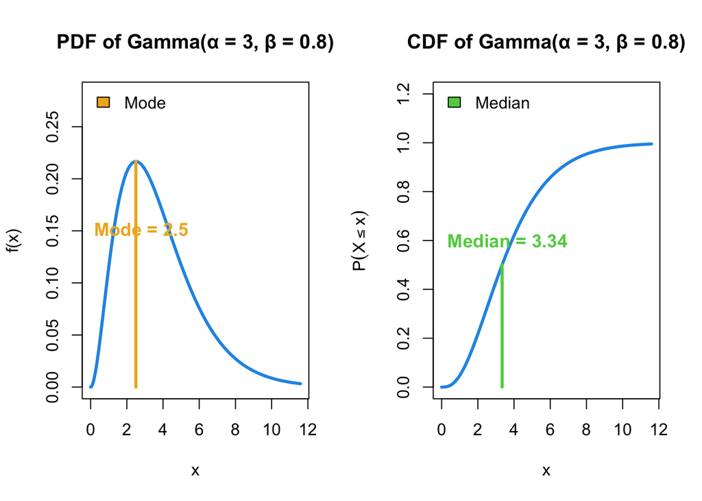

## Beta Distribution

Let $X$ be a continuous random variable following a Beta distribution with parameters $\alpha > 0$ and $\beta > 0$, written $X \sim \text{Beta}(\alpha, \beta)$.

The Probability Density Function (PDF):

Otherwise,
$$f_X(x) = 0$$

The Cumulative Distribution Function (CDF) for $0 \leq x \leq 1$:
$$\begin{equation}
F_X(x)= F(x;\alpha,\beta) =\frac{\displaystyle\int_{0}^{x}
t^{\alpha-1}(1 - t)^{\beta-1}dt}{B(\alpha,\beta)}
\end{equation}$$
where $B(\alpha,\beta)$is Beta Function.

The Expectation and variance:

$$E[X] = \frac{\alpha}{\alpha + \beta}$$

$$\operatorname{Var}(X) = \frac{\alpha \beta}{(\alpha + \beta)^2 (\alpha +
\beta + 1)}$$

For Mode, when $\alpha>1$ and $\beta>1,$
$$\text{mode}=\frac{\alpha-1}{\alpha+\beta-2}$$
when $\alpha\leq1$ and $\beta>1$,
$$\text{mode}=0$$
when $\alpha>1$ and $\beta\leq1$,
$$\text{mode}=1$$
when $\alpha\leq1$ and $\beta\leq1$, there is no mode in $[0,1]$;

For Median, No simple closed-form expression. The median $m$ satisfies $F_X(m) = 0.5$.

### Further discussion of relation to another probability distribution

The Uniform distribution on [0,1] is a special case of the Beta distribution when $\alpha=1$ and $\beta=1$.

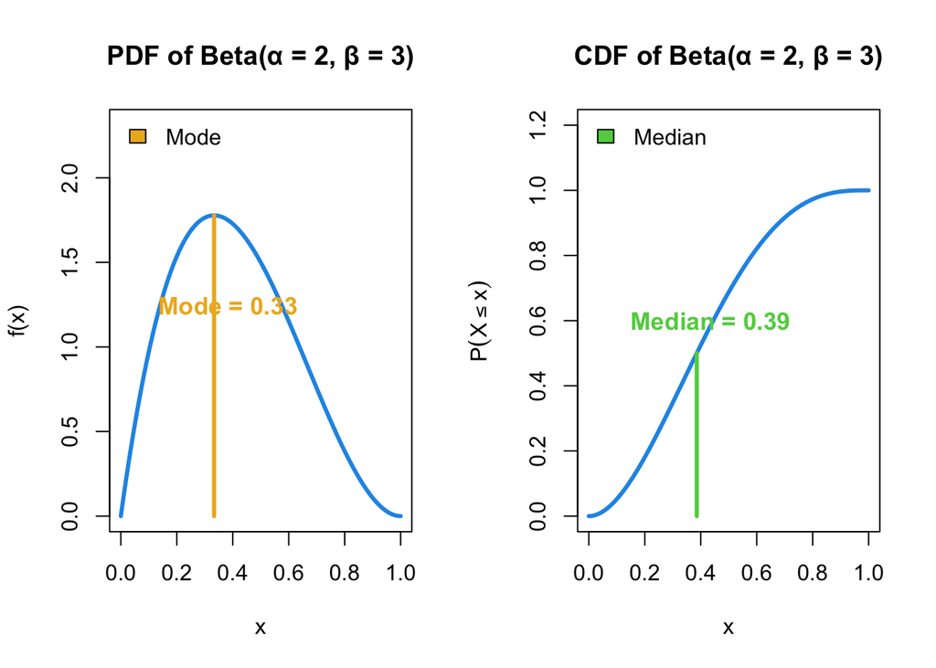

## Normal Distribution

Let $X$ be a continuous random variable following a normal distribution with mean $\mu \in \mathbb{R}$ and variance $\sigma^2 > 0$, written $X \sim N(\mu, \sigma^2)$.

The probability density function (PDF) for $x \in \mathbb{R}$ is:
$$f_X(x) = \displaystyle\frac{1}{\sqrt{2\pi}\,\sigma}
\exp\left(-\frac{(x-\mu)^2}{2\sigma^2}\right)$$

The cumulative distribution function (CDF) for $x \in \mathbb{R}$ is:
$$F_X(x) = \displaystyle\Phi\left(\frac{x-\mu}{\sigma}\right)$$
where $\Phi$ is the standard normal CDF: $\displaystyle\Phi(z) = \frac{1}{\sqrt{2\pi}} \int_{-\infty}^z e^{-t^2/2}\, dt$.

The expectation and variance are:
$$E[X] = \mu, \quad \operatorname{Var}(X) = \sigma^2$$

The mode is:
$$\text{Mode} = \mu$$

The median is:
$$\text{Median} = \mu$$

When $\mu = 0$ and $\sigma = 1$, $Z \sim N(0, 1)$ is the standard normal distribution with PDF:
$$\phi(z) = \displaystyle\frac{1}{\sqrt{2\pi}} \ e^{-z^2/2}$$

### Further discussion (Property-Transformation)

The normally distributed random variable $X \sim N(\mu,\sigma^2)$ can be transformed into the standard normal distribution $Z \sim N(0,1)$ through a simple linear shift and scaling:
$$Z = \frac{X - \mu}{\sigma}$$
Then, it is easy to calculate through Normal Statistical Tables.

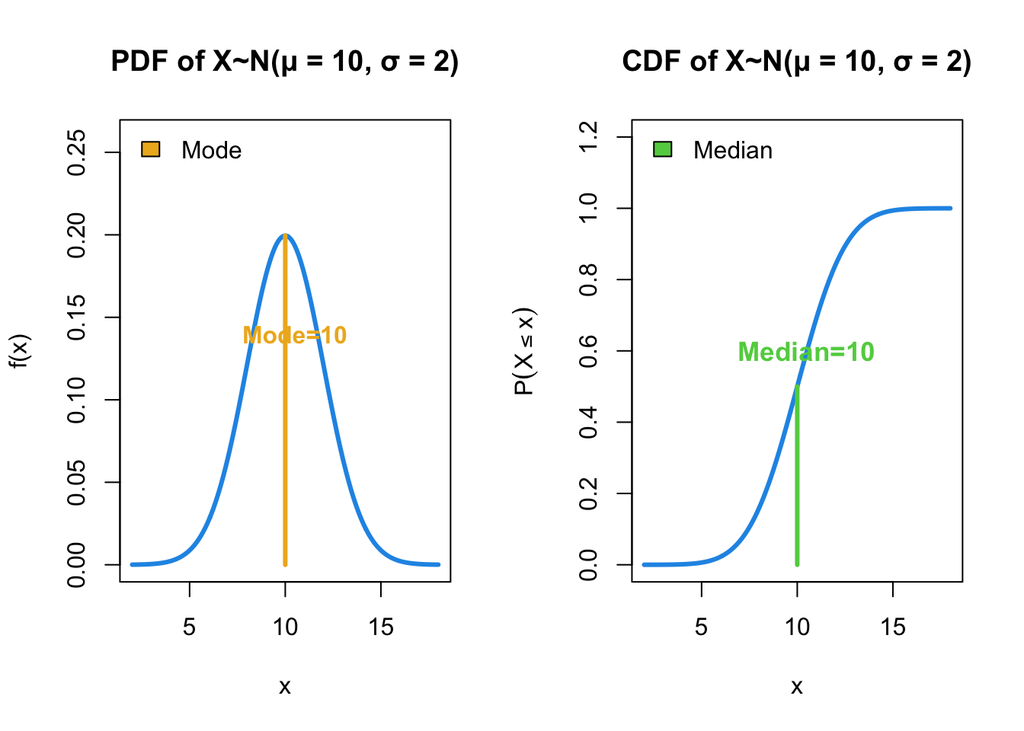